# Reproducible Research Course Project Week4

Yue Li

February 18, 2018

## Background

Storms and other severe weather events can cause both public health and economic problems for communities and municipalities. Many severe events can result in fatalities, injuries, and property damage, and preventing such outcomes to the extent possible is a key concern.

This project involves exploring the U.S. National Oceanic and Atmospheric Administration’s (NOAA) storm database. This database tracks characteristics of major storms and weather events in the United States, including when and where they occur, as well as estimates of any fatalities, injuries, and property damage.

## Data Loading

First, data is downloaded from the link below:

```r
suppressPackageStartupMessages(library(ggplot2))
suppressPackageStartupMessages(library(plyr))
url <- "https://d396qusza40orc.cloudfront.net/repdata%2Fdata%2FStormData.csv.bz2"
download.file(url, "RawData.csv.bz2")
mydata <- read.csv("RawData.csv.bz2")
```

## Data Processing

Take a subset of the data to include the variables of interest: **FATALITIES** and **INJURIES** would be used in question 1; **PROPDMG**, **CROPDMG**, **PROPDMGEXP** and **CROPDMGEXP** would be used in question 2:

```r
dim(mydata)
```

```
## [1] 902297     37
```

```r
mydata_sub <- mydata[,c("EVTYPE","FATALITIES","INJURIES", "PROPDMG", "PROPDMGEXP", "CROPDMG", "CROPDMGEXP")]
head(mydata_sub)
```

```
##    EVTYPE FATALITIES INJURIES PROPDMG PROPDMGEXP CROPDMG CROPDMGEXP
## 1 TORNADO          0       15    25.0          K       0
## 2 TORNADO          0        0     2.5          K       0
## 3 TORNADO          0        2    25.0          K       0
## 4 TORNADO          0        2     2.5          K       0
## 5 TORNADO          0        2     2.5          K       0
## 6 TORNADO          0        6     2.5          K       0
```

```r
unique(mydata_sub$PROPDMGEXP)
```

```
##  [1] K M   B m + 0 5 6 ? 4 2 3 h 7 H - 1 8
## Levels:  - ? + 0 1 2 3 4 5 6 7 8 B h H K m M
```

```r
unique(mydata_sub$CROPDMGEXP)
```

```
## [1]   M K m B ? 0 k 2
## Levels:  ? 0 2 B k K m M
```

As we can see, **PROPDMGEXP** and **CROPDMGEXP** need to be preprocessed in questions 2. According to the column definition, the actual damage in $USD in indicated by **PROPDMGEXP** and **CROPDMGEXP**. We will map them as follows:

```r
mydata_sub$PROPDMGEXP = mapvalues(mydata_sub$PROPDMGEXP, from = c("K", "M", "", "B", "m", "+", "0", "5", "6", "?","4","2","3","h","7","H","-","1","8"), to = c(10^3,10^6,1,10^9,10^6,1,1,10^5,10^6,1,10^4,10^2,10^3,10^3,10^7,10^2,1,1,10^8))

mydata_sub$CROPDMGEXP = mapvalues(mydata_sub$CROPDMGEXP, from = c("M", "K", "m", "B", "?", "0", "k", "2"), to = c(10^6,10^3,10^3,10^9,1,1,10^3,10^2))
```

## Questions 1

Across the United States, which types of events (as indicated in the 𝙴𝚅𝚃𝚈𝙿𝙴 variable) are most harmful with respect to population health?

From fatalities point of view:

```r
# Aggregate fatalities by event type
Death_by_Evt <- aggregate(mydata_sub$FATALITIES, by = list(mydata_sub$EVTYPE), FUN = sum)
colnames(Death_by_Evt) <- c("EVENTTYPE", "FATALITIES")

# Reorder the data to show the most harmful event type
Death_by_Evt_Ord <- Death_by_Evt[order(Death_by_Evt$FATALITIES, decreasing = TRUE),]
Death_by_Evt_Ord[c(1:10),]
```

```
##          EVENTTYPE FATALITIES
## 834        TORNADO       5633
## 130 EXCESSIVE HEAT       1903
## 153    FLASH FLOOD        978
## 275           HEAT        937
## 464      LIGHTNING        816
## 856      TSTM WIND        504
## 170          FLOOD        470
## 585    RIP CURRENT        368
## 359      HIGH WIND        248
## 19       AVALANCHE        224
```

From Injuries point of view:

```r
# Aggregate injuries by event type
Injury_by_Evt <- aggregate(mydata_sub$INJURIES, by = list(mydata_sub$EVTYPE), FUN = sum)
colnames(Injury_by_Evt) <- c("EVENTTYPE", "INJURIES")

# Reorder the data to show the most harmful event type
Injury_by_Evt_Ord <- Injury_by_Evt[order(Injury_by_Evt$INJURIES, decreasing = TRUE),]
Injury_by_Evt_Ord[c(1:10),]
```

```
##             EVENTTYPE INJURIES
## 834           TORNADO    91346
## 856         TSTM WIND     6957
## 170             FLOOD     6789
## 130    EXCESSIVE HEAT     6525
## 464         LIGHTNING     5230
## 275              HEAT     2100
## 427         ICE STORM     1975
## 153       FLASH FLOOD     1777
## 760 THUNDERSTORM WIND     1488
## 244              HAIL     1361
```

## Result

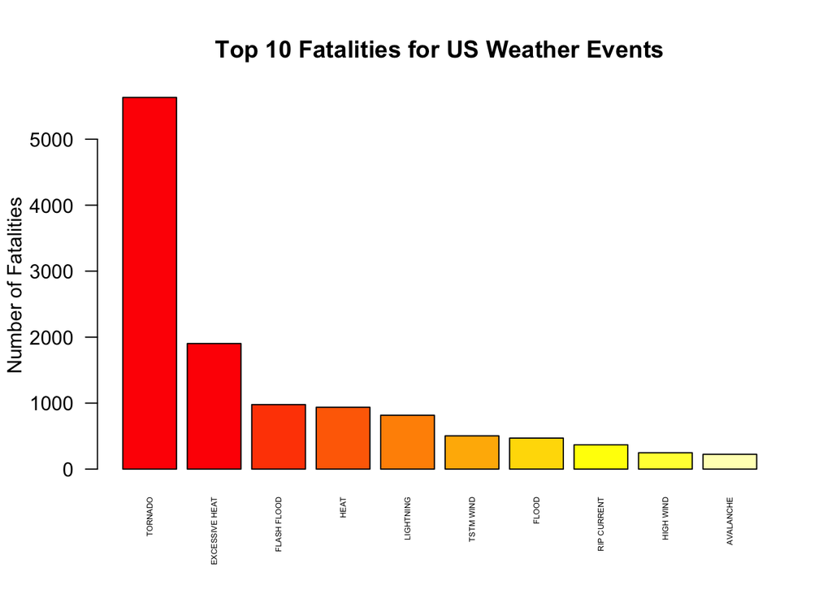

```r
# Plot the top 10 event type with most fatalities
barplot(height = (Death_by_Evt_Ord$FATALITIES[1:10]), names.arg = Death_by_Evt_Ord$EVENTTYPE[1:10],col=heat.colors(10, alpha = 1), main = "Top 10 Fatalities for US Weather Events", ylab = "Number of Fatalities", las = 2, cex.names= 0.4)
```

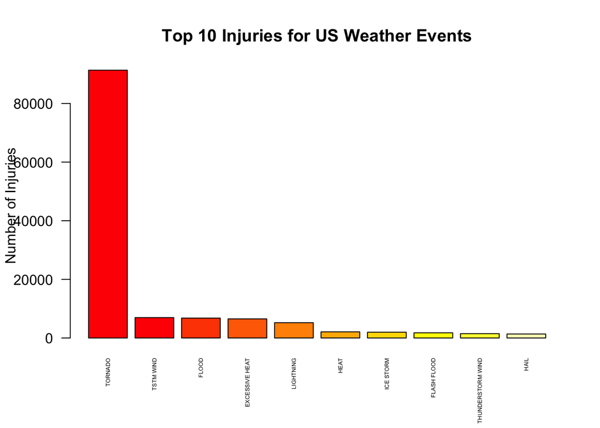

```r
# Plot the top 10 event type with most injuries
barplot(height = (Injury_by_Evt_Ord$INJURIES[1:10]), names.arg = Injury_by_Evt_Ord$EVENTTYPE[1:10],col=heat.colors(10, alpha = 1), main = "Top 10 Injuries for US Weather Events", ylab = "Number of Injuries", las = 2, cex.names= 0.4)
```

As shown in the plots, **Tornado** cause the highest fatalities and injuries.

## Questions 2

Across the United States, which types of events have the greatest economic consequences?

We define the economic damage as the sum of crop damage and property damage.

```r
mydata_sub$TOTALDMG <- 10^(as.numeric(mydata_sub$PROPDMGEXP)) * mydata_sub$PROPDMG + 10^(as.numeric(mydata_sub$CROPDMGEXP)) * mydata_sub$CROPDMG

# Aggregate economic damage by event type
EcoDMG_by_Evt <- aggregate(mydata_sub$TOTALDMG, by = list(mydata_sub$EVTYPE), FUN = sum)
colnames(EcoDMG_by_Evt) <- c("EVENTTYPE", "TOTALDMG")

# Reorder the data to show the most harmful event type
EcoDMG_by_Evt_Ord <- EcoDMG_by_Evt[order(EcoDMG_by_Evt$TOTALDMG, decreasing = TRUE),]
EcoDMG_by_Evt_Ord[c(1:10),]
```

```
##             EVENTTYPE     TOTALDMG
## 170             FLOOD 166410984870
## 244              HAIL  75896547177
## 411 HURRICANE/TYPHOON  70770305100
## 834           TORNADO  67217119445
## 670       STORM SURGE  43324036000
## 153       FLASH FLOOD  35861748195
## 856         TSTM WIND  15805913990
## 95            DROUGHT  15641841000
## 402         HURRICANE  14867629010
## 760 THUNDERSTORM WIND  10475828660
```

## Result

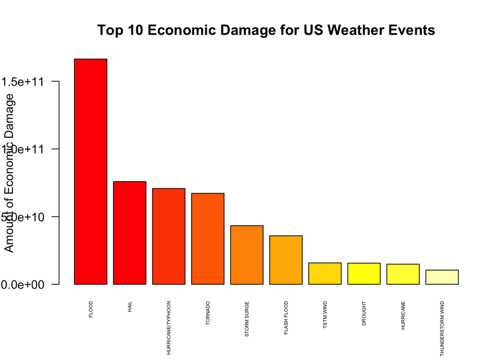

```r
# Plot the top 10 event type with most economic damage
barplot(height = (EcoDMG_by_Evt_Ord$TOTALDMG[1:10]), names.arg = EcoDMG_by_Evt_Ord$EVENTTYPE[1:10],col=heat.colors(10, alpha = 1), main = "Top 10 Economic Damage for US Weather Events", ylab = "Amount of Economic Damage", las = 2, cex.names= 0.4)
```

As shown in the plots, **Flood** cause the highest economic damage.